# Tangency portfolio and Black-Litterman approach

2023-10-25

# 1. Global Minimum Volatility portfolio (GMV) on an equity portfolio

## 1.1 Packages

We import the necessary libraries to perform the first analysis.

1. **library(tidyverse):** The tidyverse package constitutes a collection of R packages meticulously designed to work seamlessly in unison for data manipulation, visualization, and analysis. It encompasses packages like ggplot2 for data visualization, dplyr for data manipulation, tidyr for data tidying, and more. Loading tidyverse avails all these packages for utilization during your R session, streamlining your data analysis workflow.
2. **library(quantmod):** The quantmod package primarily caters to quantitative financial modeling and analysis. It furnishes an array of functions and tools for handling financial data, such as downloading and managing stock price data, conducting technical analysis, and modeling financial time series.
3. **library(DataExplorer):** The DataExplorer package serves the purpose of preliminary data exploration and analysis. It offers functions to generate summary statistics, visualize missing data, plot variable distributions, and more. It can aid in obtaining a quick overview of your data before delving into more extensive analyses.
4. **library(corrplot):** The corrplot package specializes in visualizing correlation matrices. It provides functions for generating visually appealing and informative correlation plots, which prove valuable for comprehending relationships between variables within your data.
5. **library(scales):** The scales package provides an assortment of scales and formatting functions tailored for R graphics. It is often employed in conjunction with other plotting packages, such as ggplot2, to customize the appearance of plots, including axes, labels, and color scales.

```r
library(tidyverse)
library(quantmod)
```

```r
library(DataExplorer)
library(corrplot)
library(scales)
```

## 1.2 Investment universe

In our portfolio management project, we have carefully chosen a set of twenty stocks from a larger universe of investments. This selection represents the most significant companies in the US equity market, primarily based on their market capitalization. By analyzing these stocks, our objective is to gain valuable insights into the strategies that can be employed for managing investments in the US equity market.

Our choice of stocks is guided by several key considerations:

- **Investment universe:** Our selection is drawn from a universe of stocks that encompasses twenty well-established companies within the US equity market. These companies are known for their substantial market presence and are recognized leaders in their respective industries.
- **Market capitalization focus:** We have chosen stocks with an emphasis on market capitalization. Larger market capitalization often indicates stability and lower volatility, making these stocks appealing for various investment strategies.
- **US equity market perspective:** Our project primarily targets insights related to the US equity market. The chosen stocks provide a representative snapshot of the investment landscape in one of the world’s largest and most influential equity markets.
- **Diversification:** To create a well-rounded portfolio, we have ensured diversification across different sectors and industries. Diversification is essential in portfolio management as it spreads risk and mitigates overexposure to a single sector.
- **Market visibility:** The selected companies are not only well-regarded in the financial sector but are also widely recognized in popular culture. Their performance is closely monitored, and they often hold significant sway over market indices.
- **Historical data and research:** These stocks have a rich history of performance data and have been the subject of extensive research. Access to their historical data is abundant, making them suitable for rigorous portfolio management analysis and research.

The provided R code defines the stock tickers for these companies, allowing you to access financial data. This data can then be employed to conduct a range of analyses, such as return calculations, risk assessments, and portfolio optimization, to test and implement various investment strategies on the US equity market.

```r
# Define the stock tickers you want to fetch data for
stock_tickers <- c("AAPL", "MSFT", "GOOGL", "AMZN", "TSLA", "NVDA", "PYPL", "CMCSA", "ADBE", "ASML",
                   "CSCO", "PEP", "AVGO", "TMUS", "INTC", "TXN", "AMGN", "NFLX", "SBUX", "AMAT")
```

```r
# Fetch historical stock data from Yahoo Finance
start_date <- "2019-01-01"  # Replace with your desired start date
end_date <- "2023-08-31"    # Replace with your desired end date
stock_data <- getSymbols(stock_tickers, from = start_date, to = end_date, auto.assign = TRUE)
```

## 1.3 Data cleaning

We perform some formatting to clean the data, an important step in performing data analysis:

- **Extracting adjusted closing prices** (lapply(stock_tickers, function(ticker) { Ad(get(ticker)) })): This code uses the lapply function to retrieve the adjusted closing prices (often used for return calculations) for a list of stock tickers. It iterates through each ticker in the stock_tickers vector and fetches the adjusted closing prices using the Ad() function from the quantmod package.
- **Combining stock returns** (do.call(cbind, stock_returns)): The code combines the extracted adjusted closing prices into a single data frame by calling cbind (column-bind) on the list of stock returns obtained in the previous step. This creates a data frame where each column represents the adjusted closing prices of a specific stock.
- **Renaming columns** (colnames(fin_prices) <- stock_tickers): The code assigns the stock tickers as column names to the combined data frame. This step ensures that each column is labeled with the corresponding stock ticker, making it easier to identify each stock’s data.
- **Handling missing data** (na.omit(fin_prices)): This line of code removes rows with missing values (usually represented as NA) from the combined data frame, fin_prices. Removing missing data is a common processing step to ensure the quality and consistency of the dataset for further analysis.

```r
# Extract adjusted closing prices (which are typically used for returns)
stock_returns <- lapply(stock_tickers, function(ticker) {
  Ad(get(ticker))
})

# Combine stock returns into a single data frame
fin_prices <- do.call(cbind, stock_returns)

# Rename columns to match your analysis
colnames(fin_prices) <- stock_tickers

# Eliminated missing data in time series
fin_return <- na.omit(fin_prices)  # Remove rows with missing values
```

We perform the arithmetic return method to compute returns for this data set. It is simple, intuitive and widely accessible. Arithmetic returns are particularly useful for performance measurement, providing a clear view of actual gains and losses. It is well-suited for short-term analysis and offer transparency.

```r
arith_fin_returns = diff(fin_return)/lag(fin_return)
head(arith_fin_returns, n=3)
```

```
##                   AAPL        MSFT       GOOGL       AMZN        TSLA
## 2019-01-02          NA          NA          NA         NA          NA
## 2019-01-03 -0.09960752 -0.03678830 -0.02769565 -0.0252415 -0.03147171
## 2019-01-04  0.04268945  0.04650945  0.05129358  0.0500640  0.05769739
##                   NVDA        PYPL       CMCSA        ADBE        ASML
## 2019-01-02          NA          NA          NA          NA          NA
## 2019-01-03 -0.06041688 -0.04268226 0.007855548 -0.03949775 -0.05515069
## 2019-01-04  0.06406776  0.05091973 0.033776246  0.04863239  0.04326951
##                   CSCO          PEP         AVGO         TMUS        INTC
## 2019-01-02          NA           NA           NA           NA          NA
## 2019-01-03 -0.03636806 -0.009333818 -0.088950956 -0.003677681 -0.05501273
## 2019-01-04  0.04504495  0.020506116  0.009828451  0.037988332  0.06136187
##                    TXN        AMGN       NFLX        SBUX        AMAT
## 2019-01-02          NA          NA         NA          NA          NA
## 2019-01-03 -0.05897292 -0.01521631 0.01322577 -0.04337713 -0.05794466
## 2019-01-04  0.04522935  0.03418363 0.09723449  0.03315462  0.06848442
```

```r
arith_fin_returns <- arith_fin_returns[-1, ]
```

In order to ensure that the data is properly imported, with non missing values and proper data cleaning procedure, we can implement this line of code in order to learn more about data.

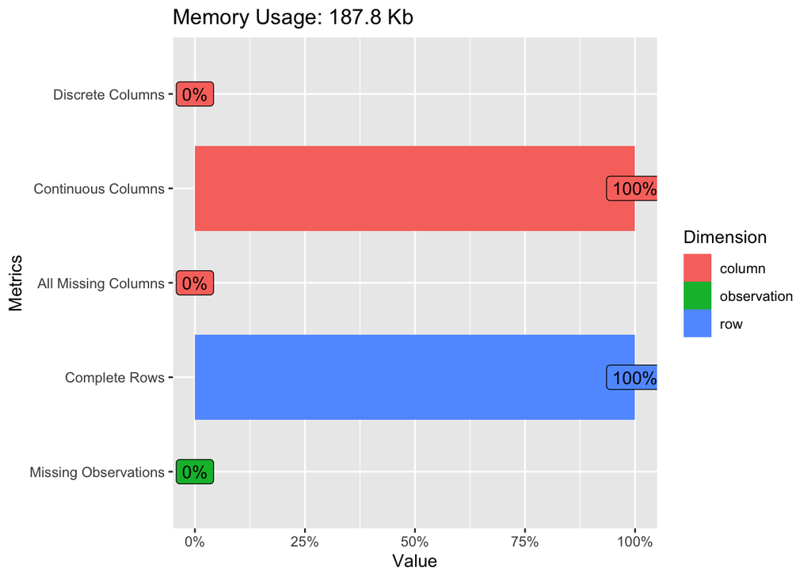

```r
plot_intro(arith_fin_returns)
```

The US stock market has performed strongly from 2019 to 2023, despite some headwinds. The S&P 500 index has returned double digit returns during this period, driven by a number of factors, including:

- **Strong economic growth:** The US economy grew at an average rate of 2.3% from 2019 to 2022, which supported corporate earnings growth.
- **Low interest rates:** The Federal Reserve kept interest rates at record lows during this period, which boosted corporate profits and made stocks more attractive to investors.
- **Government stimulus:** The US government injected a number of stimulus measures in response to the COVID-19 pandemic, which boosted consumer spending and supported the economy.

The main market movers during this period have been technology stocks, which have outperformed other sectors by a wide margin. This is due to the fact that technology companies have benefited from the shift to online shopping and working during the pandemic.

Other sectors that have performed well during this period include healthcare, consumer staples, and financials. These sectors are generally seen as more defensive, and they have tended to outperform in times of market volatility.

Some of the top performing US stocks from 2019 to 2023 include:

- **NVIDIA (TICKER: NVDA)**
- **Tesla (TICKER: TSLA)**
- **Apple (TICKER: AAPL)**
- **Microsoft (TICKER: MSFT)**
- **Alphabet (TICKER: GOOGL)**
- **Amazon (TICKER: AMZN)**

These companies have all benefited from the trends mentioned above, and they have seen their share prices rise significantly during this period. Overall, the US stock market has performed strongly from 2019 to 2023, despite some headwinds. The main market movers have been technology stocks, which have outperformed other sectors by a wide margin.

From the figure below, Nvidia (TICKER: NVDA) and Tesla (TICKER: TSLA) stock shares witnessed an unprecedented surge in attraction, making it a notable standout within our investment universe. Tesla was amon the best performing stocks in the broader investment universe selected. The surge in retail trading interest for the electric car company can explain to some extent this massive performance, especially in the wake of the post-COVID market, where intensive monetary policies prompted significant investments from both corporate and retail investors seeking higher yields.

Regarding Nvidia’s stock price, it has surged in recent years as investors have become increasingly bullish on the company’s prospects. There are a number of reasons for this, including:

- **The growth of AI:** AI is one of the most important technological trends of our time, and Nvidia’s GPUs are essential for many AI applications. As AI continues to grow, Nvidia is well-positioned to benefit.
- **The rise of the metaverse:** The metaverse is a virtual world that is still in its early stages of development, but it has the potential to be a massive market. Nvidia’s GPUs are used to power many of the technologies that will be used in the metaverse, such as virtual reality and augmented reality.
- **Nvidia’s strong financial performance:** Nvidia has been delivering strong financial performance for many years. In the most recent quarter, the company reported revenue of $8.29 billion and earnings per share of $1.32, both of which beat analyst expectations.

Given Nvidia’s strong position in the AI and metaverse markets, it is not surprising that investors are paying attention to the stock. The company is also well-managed and has a strong track record of innovation.

Here are some specific reasons why investors are interested in NVDA stock amid a rising war in AI and LLM:

- **Nvidia is a leader in the development of AI hardware and software.** The company’s GPUs are used by many of the world’s leading AI researchers and companies.
- **Nvidia is well-positioned to benefit from the growth of LLM.** LLMs are a new type of AI that can generate text, translate languages, write different kinds of creative content, and answer your questions in an informative way. Nvidia’s GPUs are essential for training and running LLMs.
- **Nvidia is investing heavily in the research and development of new AI technologies.** The company is committed to maintaining its leadership position in the AI market.

Overall, Nvidia is a well-established company with a strong track record of innovation. The company is well-positioned to benefit from the growth of AI and LLM, which is why investors are paying attention to the stock.

The code allowed us to plot returns into a time series, providing a clear visualization of stock performance during the specified period.

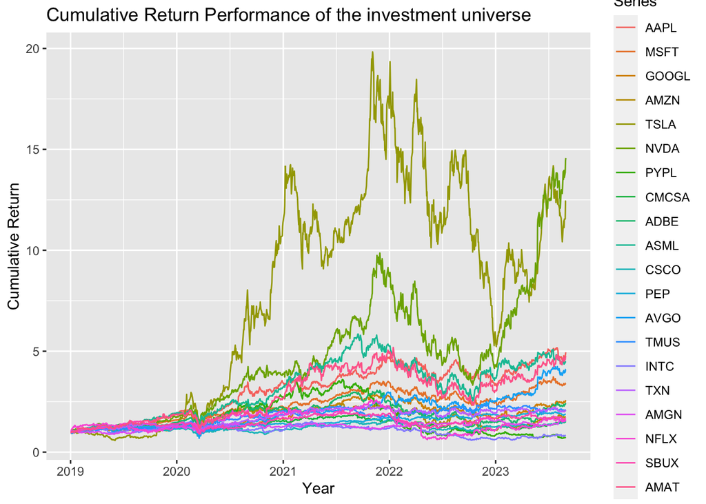

```r
# Calculate Cumulative Returns
cumulative_returns <- cumprod(1 + arith_fin_returns)

# Plot Cumulative Return Performance
library(ggplot2)
autoplot(cumulative_returns, facets = NULL) +
  ggtitle("Cumulative Return Performance of the investment universe") +
  ylab("Cumulative Return") +
  xlab("Year")
```

We can define the minimum volatility portfolio as a portfolio of assets with the lowest possible risk for an investor and is located on the far-left side of the efficient frontier. Note that the minimum volatility portfolio is also called the minimum variance portfolio or more precisely the global minimum volatility portfolio (to distinguish it from other optimal portfolios obtained for higher risk levels).

To implement to global minimum variance portfolio, we need to compute the covariance matrix as an input parameter for the Markowitz optimization model.

```r
cov_matrix <- cov(arith_fin_returns)
```

Correlation plays an important role in a Markowitz allocation framework, where diversification can be achieved when allocating capital to poorly or negatively correlated assets.

The concept of diversification seeks to enhance returns while minimizing risk by investing in a variety of assets that will react differently to the same event (s). For example, whenever there is unfavorable news about a certain event, i.e. 2008 sub prime mortgage crisis, the stock market typically declines dramatically. Simultaneously, the same news has generally benefited the price of specific assets, such as gold. As a result, portfolio diversification should include not just diverse stocks inside and outside of the same industry, but also diverse asset classes, such as bonds and commodities. The diversification effect is a term that relates to the link between portfolio correlations and diversification. When there is an imperfect correlation between assets (positive or negative), the diversification effect occurs. It is a critical and successful risk mitigation method since risk mitigation may be accomplished without sacrificing profits. As a result, any prudent investor who is ‘risk cautious’ will diversify to a certain extent.

Here, we observe opportunities for diversification within our investment universe. For instance, we notice that stocks often categorized as defensive plays can serve as effective diversification instruments when combined with more aggressive stocks. In this context, consider Amgen Inc. (TICKER: AMGN) in the healthcare industry, which exhibits a neutral correlation when compared to a stock like Tesla (TICKER: TSLA). Similar logic applies to a stock such as PepsiCo Inc. (TICKER: PEP) in relation to Tesla. It’s worth noting that within our investment universe, we do not find negative correlations, as all the assets exhibit some degree of correlation to one another.

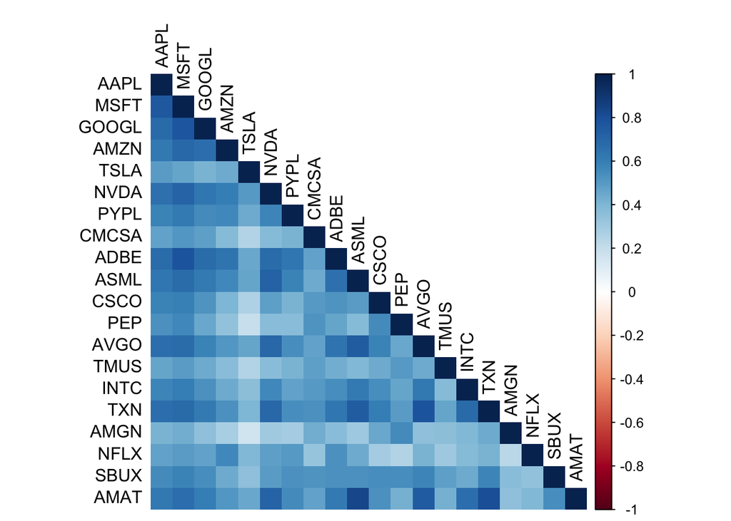

```r
corrplot(cor(arith_fin_returns), type='lower',
         method = "shade", tl.col = 'black', cl.pos = "r", tl.cex = 1)
```

To further complement the analysis of the data gathered, we can run a statistical analysis of the first moments of the distribution to assess the performance of each stock and understand their behavior during the time frame observed. NB: Figures obtained from this statistical analysis are given on a daily return basis.

```r
summary(arith_fin_returns)
```

```
##      Index                 AAPL                MSFT
##  Min.   :2019-01-03   Min.   :-0.128647   Min.   :-0.147390
##  1st Qu.:2020-03-04   1st Qu.:-0.008324   1st Qu.:-0.008514
##  Median :2021-05-03   Median : 0.001423   Median : 0.001101
##  Mean   :2021-05-01   Mean   : 0.001580   Mean   : 0.001240
##  3rd Qu.:2022-06-30   3rd Qu.: 0.012965   3rd Qu.: 0.011377
##  Max.   :2023-08-30   Max.   : 0.119808   Max.   : 0.142169
##      GOOGL                AMZN                 TSLA
##  Min.   :-0.116341   Min.   :-0.1404944   Min.   :-0.210628
##  1st Qu.:-0.008504   1st Qu.:-0.0109222   1st Qu.:-0.017579
##  Median : 0.001013   Median : 0.0009821   Median : 0.002178
##  Mean   : 0.001012   Mean   : 0.0007304   Mean   : 0.003009
##  3rd Qu.: 0.011129   3rd Qu.: 0.0120408   3rd Qu.: 0.023022
##  Max.   : 0.096202   Max.   : 0.1353590   Max.   : 0.198949
##       NVDA                PYPL                CMCSA
##  Min.   :-0.184521   Min.   :-0.2459044   Min.   :-0.0913074
##  1st Qu.:-0.015158   1st Qu.:-0.0139465   1st Qu.:-0.0079128
##  Median : 0.003060   Median : 0.0010063   Median : 0.0006982
##  Mean   : 0.002838   Mean   : 0.0001388   Mean   : 0.0005144
##  3rd Qu.: 0.020068   3rd Qu.: 0.0139848   3rd Qu.: 0.0095182
##  Max.   : 0.243696   Max.   : 0.1410978   Max.   : 0.1256441
##       ADBE                ASML                CSCO
##  Min.   :-0.167932   Min.   :-0.173492   Min.   :-0.1373036
##  1st Qu.:-0.010223   1st Qu.:-0.011637   1st Qu.:-0.0075007
##  Median : 0.001809   Median : 0.001160   Median : 0.0005940
##  Mean   : 0.001035   Mean   : 0.001622   Mean   : 0.0005255
##  3rd Qu.: 0.013235   3rd Qu.: 0.016426   3rd Qu.: 0.0088840
##  Max.   : 0.177193   Max.   : 0.145732   Max.   : 0.1337351
##       PEP                  AVGO                TMUS
##  Min.   :-0.1142832   Min.   :-0.199129   Min.   :-0.1120879
##  1st Qu.:-0.0049844   1st Qu.:-0.010200   1st Qu.:-0.0078173
##  Median : 0.0006835   Median : 0.001450   Median : 0.0008011
##  Mean   : 0.0006349   Mean   : 0.001479   Mean   : 0.0007958
##  3rd Qu.: 0.0065278   3rd Qu.: 0.013311   3rd Qu.: 0.0095050
##  Max.   : 0.1293660   Max.   : 0.158337   Max.   : 0.1178280
##       INTC                 TXN                  AMGN
##  Min.   :-0.1804153   Min.   :-0.1182574   Min.   :-8.261e-02
##  1st Qu.:-0.0111180   1st Qu.:-0.0103406   1st Qu.:-7.367e-03
##  Median : 0.0002334   Median : 0.0007667   Median :-4.019e-05
##  Mean   : 0.0001528   Mean   : 0.0008089   Mean   : 5.045e-04
##  3rd Qu.: 0.0120075   3rd Qu.: 0.0122604   3rd Qu.: 7.933e-03
##  Max.   : 0.1952129   Max.   : 0.1352941   Max.   : 1.090e-01
##       NFLX                 SBUX                 AMAT
##  Min.   :-0.3511660   Min.   :-0.1620426   Min.   :-0.203576
##  1st Qu.:-0.0137289   1st Qu.:-0.0083442   1st Qu.:-0.014175
##  Median : 0.0007823   Median : 0.0006782   Median : 0.001367
##  Mean   : 0.0008648   Mean   : 0.0006439   Mean   : 0.001764
##  3rd Qu.: 0.0146454   3rd Qu.: 0.0093759   3rd Qu.: 0.018498
##  Max.   : 0.1685434   Max.   : 0.1473032   Max.   : 0.128131
```

In portfolio management, statistical analysis can help understand financial patterns in data.

Density plots, also known as probability density function plots, serve the purpose of visualizing data distributions. They offer insights into the shape, spread, and central tendencies of data, making them crucial for assessing the nature of financial asset returns. These plots help portfolio managers identify departures from expected distributions, facilitating informed investment decisions. Together, these techniques aid in the exploration and assessment of financial data, enabling portfolio managers to make more informed and data-driven choices in their investment strategies.

We can run some more advanced statistical analysis to understand the asset return behavior of the equities selected in this analysis.

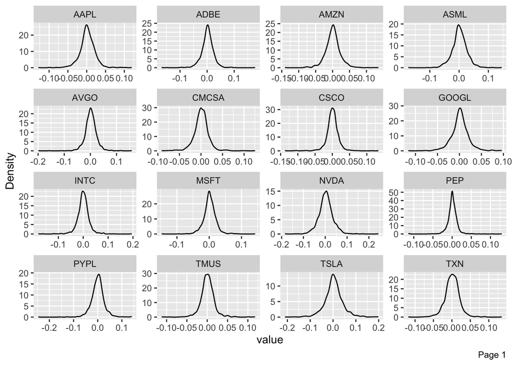

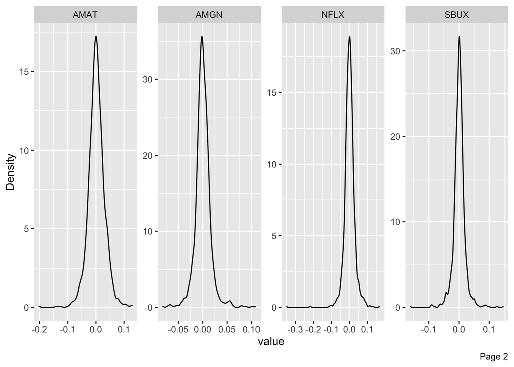

```r
# Advanced statistical analysis for the dataset

plot_density(arith_fin_returns)
```

```r
#plot_qq(arith_fin_returns)
```

# 2. Modelling part

Modern Portfolio Theory (MPT) is founded on several market and investor assumptions. Several of these assumptions are stated explicitly, while others are implied. Markowitz’s contributions to (MPT) in portfolio selection are based on the following basic assumptions:

- Investors are rational (they seek to maximize returns while minimizing risk, or minimize risk while maximize return).
- Investors will accept increased risk only if compensated with higher expected returns.
- Investors receive all relevant information regarding their investment decision.
- Investors can borrow or lend an unlimited amount of capital at a risk-free rate of interest.

## 2.1 Unbiased Global Minimum Variance (GMV) portfolio

In the context of time series data analysis, one of the crucial applications is the division of the data set into a training set and a testing set based on temporal order. This approach is particularly important when dealing with data that evolves over time, such as stock prices, weather observations, or economic indicators.

The training set typically comprises historical data, while the testing set contains more recent observations. This temporal separation allows for the evaluation of predictive models and forecasting techniques. By using historical data to train the model and then assessing its performance on more recent data, analysts can gauge the model’s ability to make accurate predictions and anticipate future trends. Time series data applications are essential in fields like finance, where understanding and forecasting trends over time is important.

For the purpose of modelling, we will shrink the data set into two different sub-samples. We can define the following parameters:

```r
num_rows_subsample1 <- 400
total_rows <- nrow(arith_fin_returns)
```

1. The first sub-sample will cover the first 400 trading days covered in the data set.

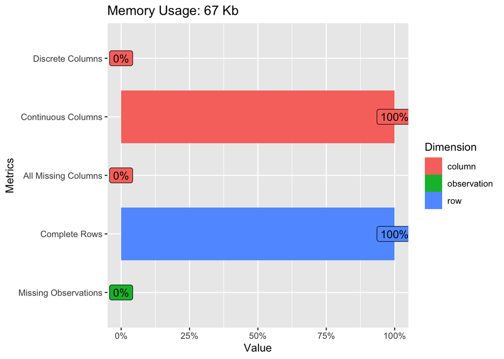

```r
subsample1 <- arith_fin_returns[1:num_rows_subsample1, ]
plot_intro(subsample1)
```

2. The second sub-sample will cover the rest of the data set, covering the equivalent of 773 trading days.

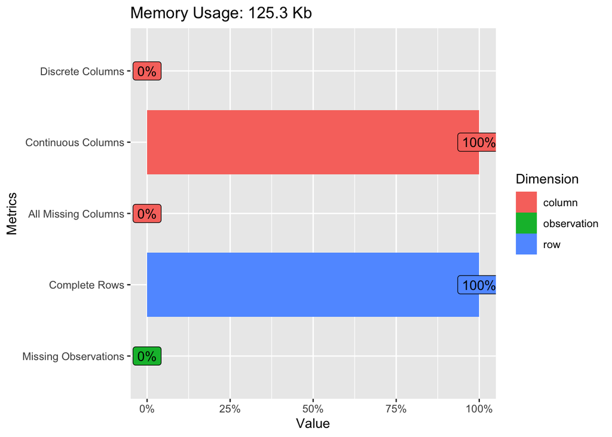

```r
subsample2 <- arith_fin_returns[(num_rows_subsample1 + 1):total_rows, ]
plot_intro(subsample2)
```

We implement the parameters of the model in order to compute the GMV:

```r
#Definition of parameters
n <- ncol(subsample1)
T <- nrow(subsample1)
e <- rep(1, n)
perio <- 252

#Compute Sigma (unbiased covariance matrix)
Sigma <- cov(subsample1) * (T - 1) / (T - n - 2) * perio
C <- t(e) %*% solve(Sigma) %*% e

#Anticipated volatility can be computed
sigmag <- sqrt(1 / C)
```

After computing the parameters required to implement the unbiased GMV portfolio, we can compute omega, representing the weightings of the portfolio as follows.

```r
omega_gmv <- 1 / as.numeric(C) * solve(Sigma) %*% e
```

We can see in this instance that the portfolio is mixed, with some long and short positions. The capital is fully invested, with some important exposure in the long part of the portfolio on stocks like Amazon (TICKER: AMZN) with 39.85%, followed by PepsiCo (TICKER: PEP) at 29.45% and ASML (TICKER: ASML) at 26.35%.

On the short part of the portfolio, we can see an important short on three stocks that can stand out: Applied Materials Inc. (TICKER: AMAT) -24.07%, Adobe (TICKER: ADBE) at -19.90% and NVIDIA Corp. (TICKER: NVDIA) at -18.28%.

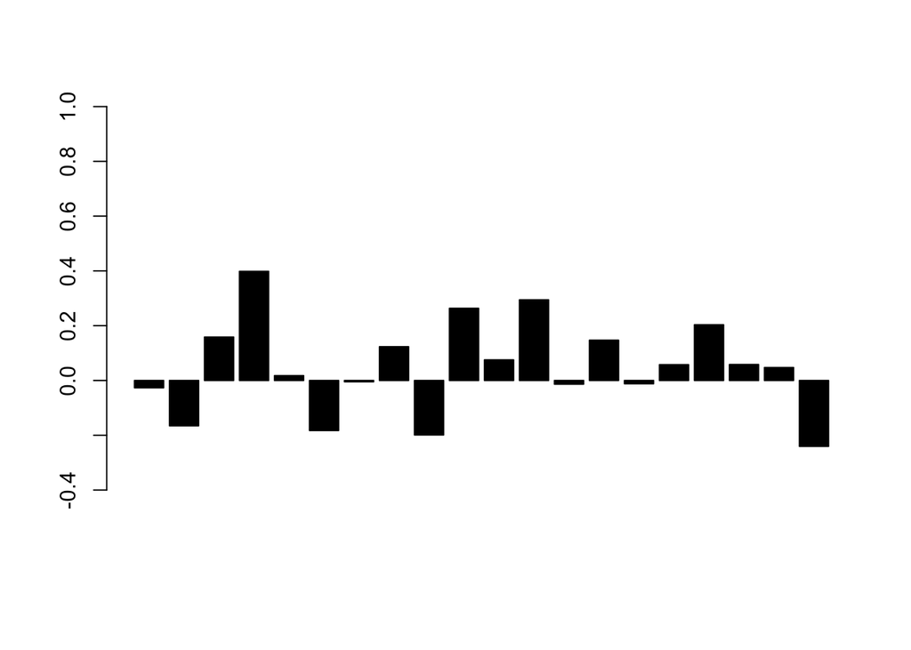

```r
barplot(as.numeric(omega_gmv), col = 'black', ylim = c(-0.5, 1))
```

## 2.2 Implementation of Principal Component Analysis (PCA)

Principal Component Analysis (PCA) is a technique used to analyze and reduce the dimensionality of a dataset while retaining as much variance as possible. We perform the PCA analysis using the second subsample starting from the trading day number 401 of the sample to the trading day number 1174.

```r
pca_result <- prcomp(subsample2, center = TRUE, scale = TRUE)

#Extract principal component loadings
loadings <- pca_result$rotation

#Variance explained by each principal component
var_explained <- (pca_result$sdev^2) / sum(pca_result$sdev^2)

#We select the number of components for the PCA
num_components <- 3  # Adjust as needed

#We compute the weights of the PCA in the portfolio.
weights_pca <- loadings[, 1:num_components] / rowSums(loadings[, 1:num_components])
```

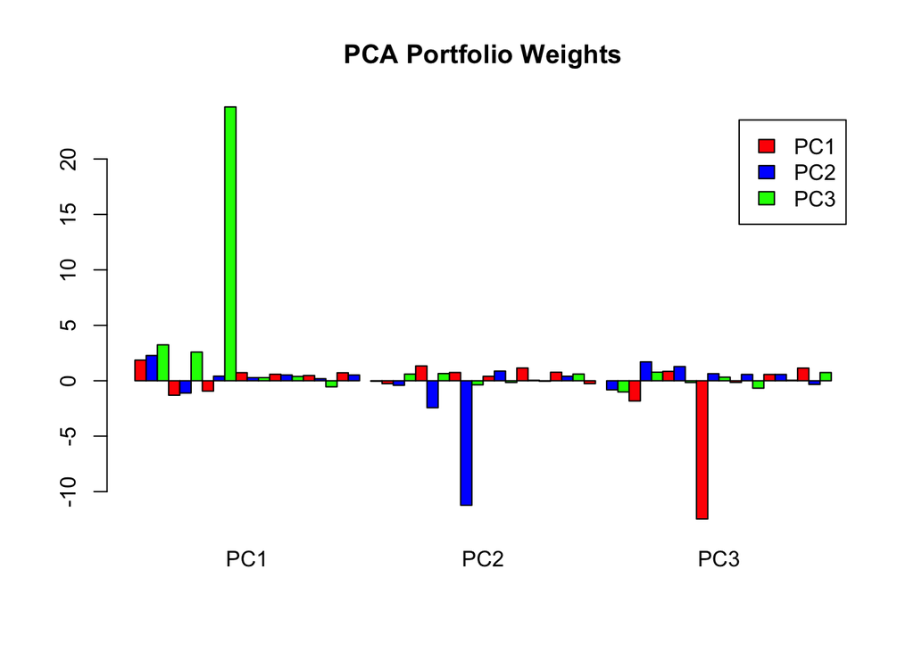

```r
my_colors <- c("red", "blue", "green") # vector of colours
barplot(weights_pca, beside = TRUE, col = my_colors,
        names.arg = colnames(weights_pca),
        legend.text = colnames(weights_pca),
        main = "PCA Portfolio Weights")
```

# 3. Tangency portfolio and Black-Litterman approach

## 3.1 Packages

We use the following libraries:

1. **tidyverse:** This package is a powerful toolbox that combines various R packages to streamline data manipulation, visualization, and analysis. It includes versatile tools like ggplot2 for visuals, dplyr for data tweaks, and tidyr for tidying data.
2. **quantmod:** quantmod specializes in quantitative financial modeling and data analysis. It equips us with tools to handle financial data, perform technical analysis, and model financial time series.
3. **DataExplorer:** DataExplorer aids in the initial data exploration phase. It provides quick insights through functions for generating summary statistics, visualizing missing data, and plotting variable distributions.
4. **corrplot:** This package is your go-to for visualizing correlation matrices. It offers functions to create informative correlation plots, helping you grasp relationships between data variables.
5. **scales:** scales complements R graphics, especially in conjunction with ggplot2. It furnishes various scales and formatting functions to customize plot aesthetics, including axes, labels, and color scales

```r
library(tidyverse)
library(quantmod)
library(DataExplorer)
library(corrplot)
library(scales)
```

## 3.2 Investment universe

We have carefully chosen a set of five trackers (ETFs) to represent our univestment universe. An ETF can be defined as a financial product that is based on a basket of different assets, to replicate the actual performance of each selected investment. An ETF has more or less the same proportion of the underlying components of the basket, depending on the style of management of the asset manager.

Our selection strategy is based on several fundamental considerations:

- **Investment universe:** The investment universe aims at representing different asset classes in order to construct a multi-asset portfolio.
- **Diversification strategy:** Our commitment to constructing a well-rounded portfolio has been affirmed through diversification across various sectors and industries. Such diversification is a critical risk management tool, curbing overexposure to a single sector or asset class.
- **Historical data availability:** The selected trackers benefit from a rich repository of historical data and extensive research. The accessibility of such data enable these ETFs to rigorous portfolio management analysis and comprehensive research.

The provided R code defines the tickers for these trackers, allowing you to access the financial data. This data can then be employed to conduct a range of analyses, such as return calculations, risk assessments, and portfolio optimization, to test and implement various investment strategies.

```r
# Define the stock tickers you want to fetch data for
stock_tickers <- c("VTI", "EMGF", "IEF", "DBC", "GLD")

# Fetch historical stock data from Yahoo Finance
start_date <- "2019-01-01"  # Replace with your desired start date
end_date <- "2023-08-31"    # Replace with your desired end date

# Use getSymbols to fetch data for all stock tickers
stock_data <- getSymbols(stock_tickers, from = start_date, to = end_date, auto.assign = TRUE)
```

## 3.3 Data cleaning

We initiate data cleaning, a crucial step in data analysis:

```r
# Extract adjusted closing prices (which are typically used for returns)
stock_returns <- lapply(stock_tickers, function(ticker) {
  Ad(get(ticker))
})

# Combine stock returns into a single data frame
fin_prices <- do.call(cbind, stock_returns)

# Eliminate missing data in time series
fin_return <- na.omit(fin_prices)  # Remove rows with missing values
```

Arithmetic returns are used for performance assessment, offering a clear view of gains and losses, suitable for short-term analysis, and ensuring transparency.

```r
# Computation of returns
arith_fin_returns = diff(fin_return)/lag(fin_return)
head(arith_fin_returns, n=3)
```

```
##            VTI.Adjusted EMGF.Adjusted IEF.Adjusted DBC.Adjusted GLD.Adjusted
## 2019-01-02           NA            NA           NA           NA           NA
## 2019-01-03  -0.02317411   -0.02569371  0.007948790  0.008258711  0.009066170
## 2019-01-04   0.03310101    0.02979952 -0.008076397  0.013651950 -0.008086236
```

```r
arith_fin_returns <- arith_fin_returns[-1, ]
```

In order to ensure that the data is properly imported, with non missing values and proper data cleaning procedure, we can implement this line of code in order to learn more about data.

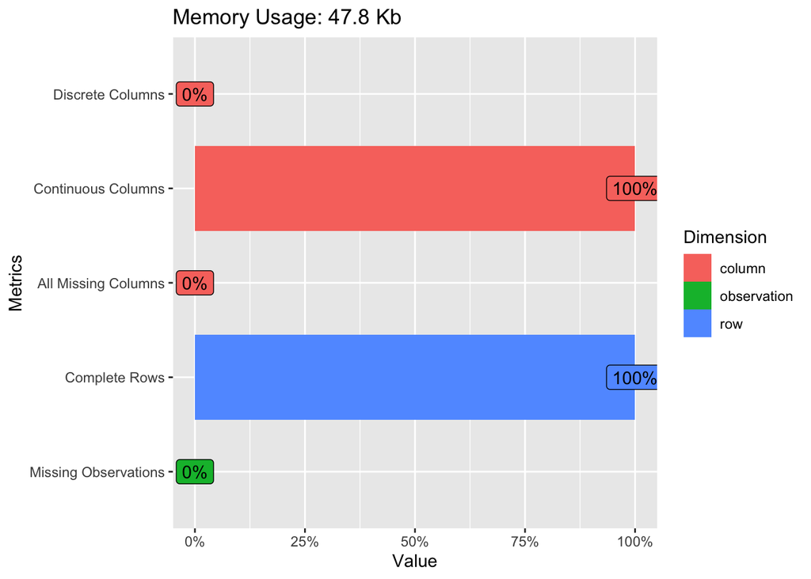

```r
# Data exploration for the return time series
plot_intro(arith_fin_returns)
```

The equity market has outperformed all of the other asset classes mentioned above since 2019 for a number of reasons.

- **Strong economic growth:** The global economy has grown at a healthy pace since 2019, which has supported corporate earnings growth. This has made equities more attractive to investors.
- **Low interest rates:** Interest rates have been low since 2019, which has made equities more attractive relative to other asset classes, such as bonds.
- **Government stimulus:** Governments around the world have enacted a number of stimulus measures to support the economy during the COVID-19 pandemic. This has boosted consumer spending and investment, which has benefited equities.
- **Corporate earnings growth:** Corporate earnings have grown strongly since 2019, as companies have benefited from the strong economy and low interest rates. This has made equities more attractive to investors.

The equity market is the riskiest of the asset classes mentioned above because it is more volatile and subject to larger swings in price. However, it has also been the most rewarding asset class over the long term, as it has generated higher returns than other asset classes, such as bonds and commodities.

Investors who are willing to take on more risk may want to consider investing in the equity market. However, it is important to note that past performance is not indicative of future results. Investors should always do their own research and consult with a financial advisor before making any investment decisions.

Here are some additional insights on the outperformance of the equity market:

- The equity market has benefited from a number of technological trends, such as the rise of e-commerce and cloud computing. These trends have led to the growth of new companies and industries, which has created new investment opportunities for investors.
- The equity market has also benefited from the globalization of the economy. Companies are now able to operate in multiple countries, which has helped them to grow their businesses and increase their profits.
- The equity market has become more accessible to individual investors in recent years. This has led to an increase in demand for equities, which has helped to drive up prices.

Overall, the equity market has outperformed all of the other asset classes mentioned above since 2019 due to a number of factors, including strong economic growth, low interest rates, government stimulus, corporate earnings growth, technological trends, globalization, and increased access for individual investors.

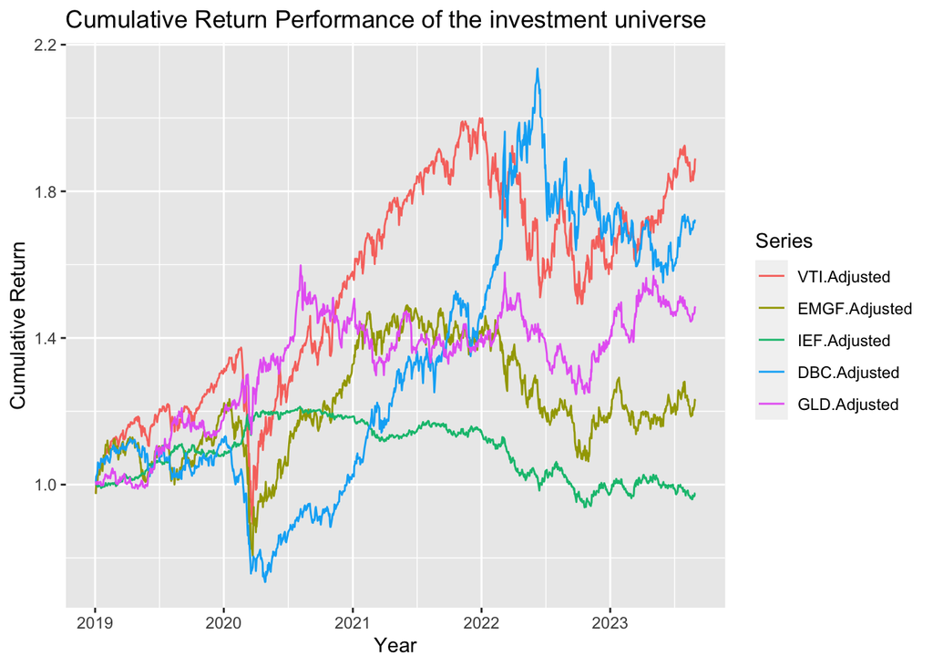

```r
# Calculate Cumulative Returns
cumulative_returns <- cumprod(1 + arith_fin_returns)

# Plot Cumulative Return Performance
library(ggplot2)
autoplot(cumulative_returns, facets = NULL) +
  ggtitle("Cumulative Return Performance of the investment universe") +
  ylab("Cumulative Return") +
  xlab("Year")
```

To enhance our data analysis, we can perform statistical analysis on the daily returns of each stock. This helps us evaluate their performance and behavior during the observed time frame. Please note that the figures derived from this analysis are presented in daily returns.

```r
# Statistical summary of returns for each asset class

summary(arith_fin_returns)
```

```
##      Index             VTI.Adjusted        EMGF.Adjusted
##  Min.   :2019-01-03   Min.   :-0.1138088   Min.   :-0.1200220
##  1st Qu.:2020-03-04   1st Qu.:-0.0054988   1st Qu.:-0.0065468
##  Median :2021-05-03   Median : 0.0010181   Median : 0.0004696
##  Mean   :2021-05-01   Mean   : 0.0006398   Mean   : 0.0002647
##  3rd Qu.:2022-06-30   3rd Qu.: 0.0075405   3rd Qu.: 0.0077083
##  Max.   :2023-08-30   Max.   : 0.0948976   Max.   : 0.0744263
##   IEF.Adjusted         DBC.Adjusted         GLD.Adjusted
##  Min.   :-2.507e-02   Min.   :-0.0794442   Min.   :-0.0536944
##  1st Qu.:-2.634e-03   1st Qu.:-0.0058102   1st Qu.:-0.0045048
##  Median : 0.000e+00   Median : 0.0014326   Median : 0.0006182
##  Mean   :-8.963e-06   Mean   : 0.0005453   Mean   : 0.0003828
##  3rd Qu.: 2.551e-03   3rd Qu.: 0.0078851   3rd Qu.: 0.0055964
##  Max.   : 2.642e-02   Max.   : 0.0479902   Max.   : 0.0485303
```

In portfolio management, statistical analysis plays a key role in understanding financial data patterns. We will focus on the density plot which visualize data distributions. This method assist portfolio managers in making data-driven investment decisions, enhancing the exploration of financial data, and understanding the behavior of selected equities’ returns. As seen from the density plots, the results are not normally distributed.

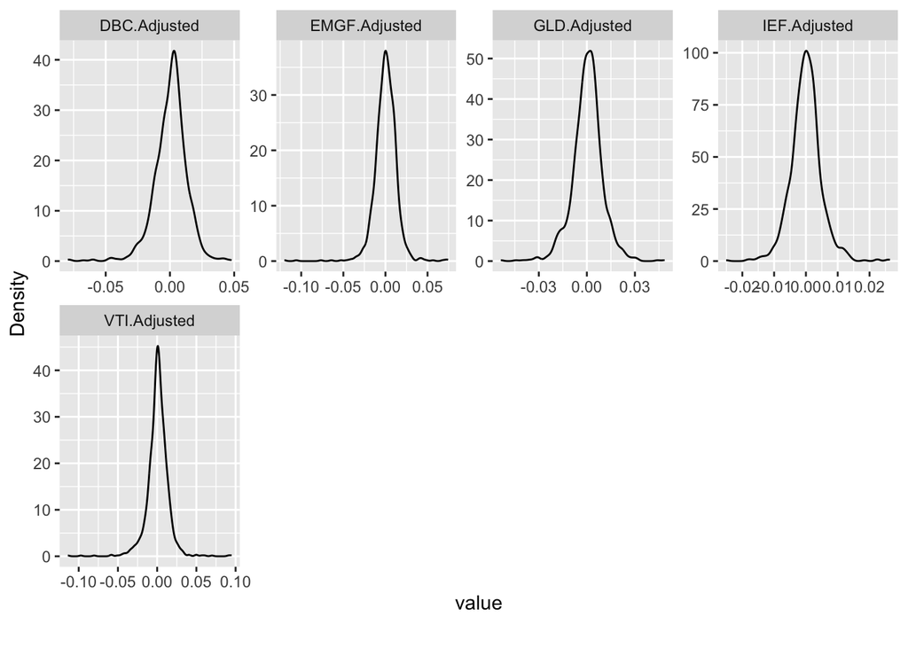

```r
# Advanced statistical analysis for the dataset

plot_density(arith_fin_returns)
```

```r
#plot_qq(arith_fin_returns)
```

Correlation is a fundamental concept related to diversification, which seeks to use poorly correlated and non correlated assets to construct a portfolio. Diversification aims to boost returns while minimizing risk by investing in assets that respond differently to various events. Prudent investors seeking risk mitigation will diversify their portfolios.

In our investment universe, opportunities for diversification arise. Defensive assets like gold (TICKER: GLD) can effectively diversify when combined with more aggressive ones. For instance, the Vanguard Total Index tracker (TICKER: VTI) has a poor correlation with gold (TICKER: GLD). iShares 7-10 years Treasuries Index tracker (TICKER: IEF) exhibits negative correlation with respect to international and emerging market equities.

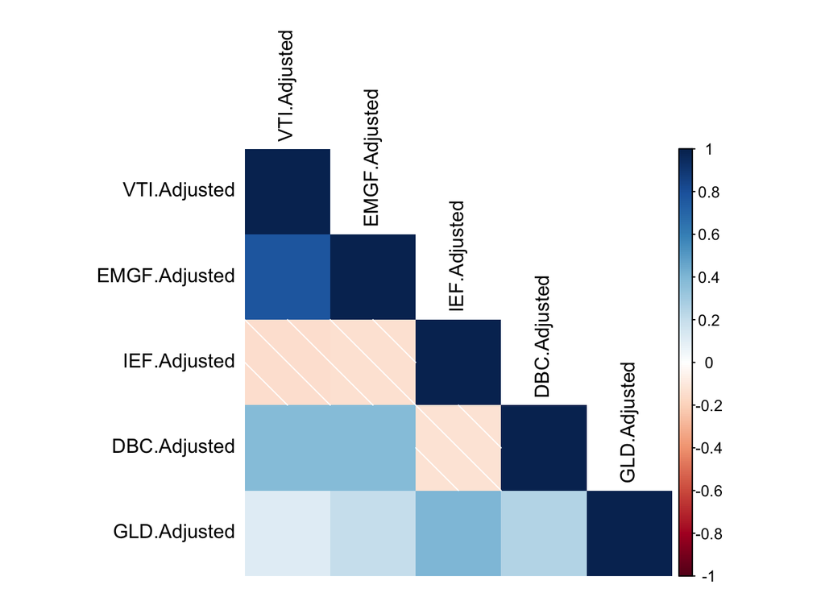

```r
# Correlation analysis

library(corrplot)
corrplot( cor(arith_fin_returns), type='lower', method = "shade", tl.col = 'black', cl.pos = "r", tl.cex = 1)
```

# 4. Modelling of the portfolio

## 4.1 Implementing the Tangency portfolio (TP)

In time series data analysis, a crucial application involves splitting the dataset into training and testing sets based on temporal order. This is vital when working with data that evolves over time, such as stock prices or weather observations.

The training set consists of historical data, while the testing set contains more recent observations. This division allows analysts to assess predictive models and forecasting techniques. By training the model on historical data and evaluating it with recent data, we can determine its ability to make accurate predictions. This is especially important in finance for understanding and forecasting trends over time.

For modeling purposes, we’ll create two sub-samples with defined parameters.

```r
# Specify the number of rows for the first subsample
num_rows_subsample1 <- 400

# Calculate the total number of rows in your dataset
total_rows <- nrow(arith_fin_returns)
```

1. The first sub-sample will cover the first 400 trading days covered in the data set.

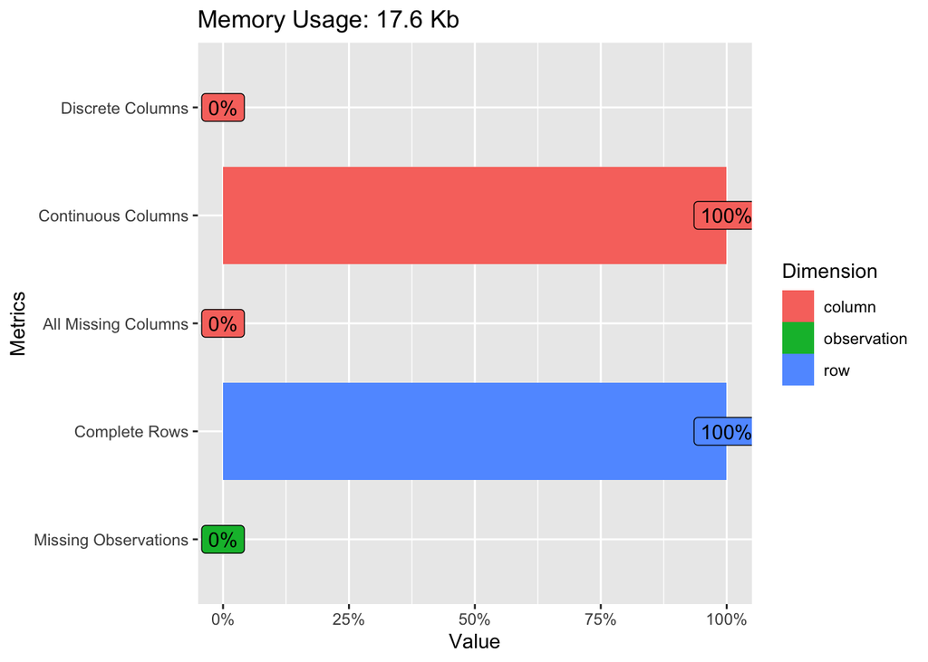

```r
# Create the first subsample
subsample1 <- arith_fin_returns[1:num_rows_subsample1, ]
plot_intro(subsample1)
```

2. The second sub-sample will cover the rest of the data set, covering the equivalent of 773 trading days.

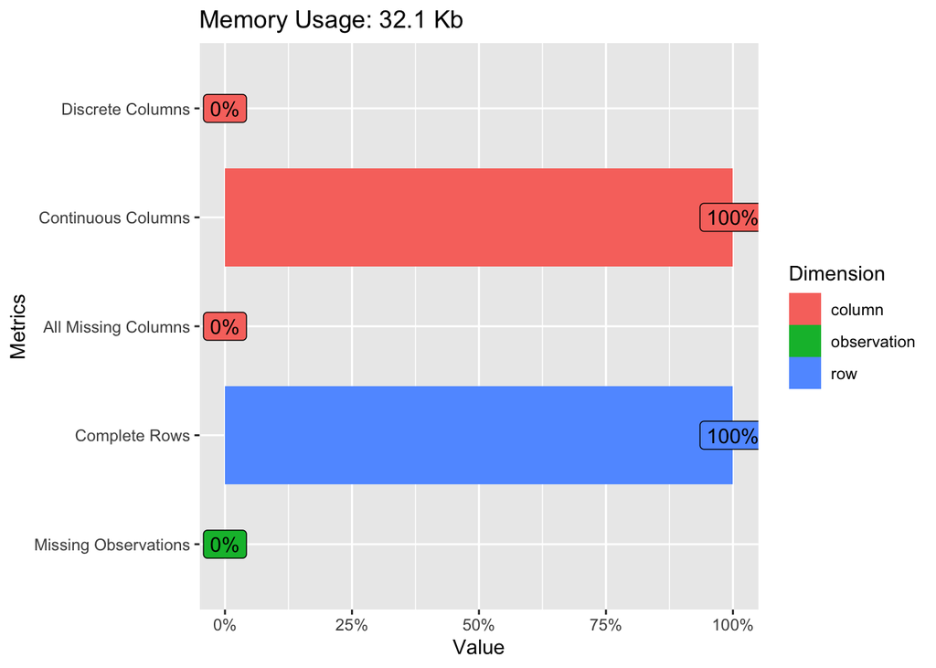

```r
# Create the second subsample by excluding the rows in the first subsample
subsample2 <- arith_fin_returns[(num_rows_subsample1 + 1):total_rows, ]
plot_intro(subsample2)
```

We implement the parameters of the model in order to compute the Tangency Portfolio:

```r
n <- ncol(subsample1)
T <- nrow(subsample1)
e <- rep(1, n)
perio <- 252
rf <- 0
```

The parameter sigma, representing the unbiased covariance matrix (similar to the procedure implemented when computing the GMV portfolio), can be computed using the following procedure:

```r
mu <- colMeans(subsample1) * perio - rf
Sigma <- cov(subsample1) * (T - 1) / (T - n - 2) * perio
A <- t(e) %*% solve(Sigma) %*% mu
omega <- 1 / as.numeric(A) * solve(Sigma) %*% mu

returns = mu %*% omega
```

The portfolio allocation consists of both long positions, where investors expect favorable returns, and short positions, where they anticipate weaker performance. Here’s a more detailed explanation of each asset class allocation:

Long Positions:

- **International Equities (Ticker: VTI, Allocation: 25.38%):** This segment of the portfolio is dedicated to international equities, with VTI making up a substantial portion at 25.38%. Investors are optimistic about the performance of international equities, which is why they have allocated a significant portion of their capital to this asset class.
- **US Short-Term Maturity Bond (Ticker: IEF, Allocation: 77.03%):** The largest allocation in the long positions is in US short-term maturity bonds, represented by IEF. This allocation, at 77.03%, indicates a strong conviction in the stability and income potential of short-term bonds.
- **Gold (Ticker: GLD, Allocation: 15.27%):** The allocation to gold, represented by GLD, has decreased to 15.27%. Gold is often considered a safe-haven asset, and this allocation suggests that investors still see value in holding gold as a hedge or store of value, albeit at a slightly reduced allocation.

Short Positions:

- **Emerging Markets (Ticker: EMGF, Allocation: -6.41%):** The short segment of the portfolio is allocated to assets where weak performance is expected. In the case of emerging markets, the allocation is bearish at -6.41%. This indicates that investors are taking a negative stance on the performance of emerging market assets, expecting their values to decline.
- **Commodities (Ticker: DBC, Allocation: -11.26%):** The allocation to commodities, represented by DBC, is even more conservative at -11.26%. This suggests a strongly bearish outlook on commodities, where investors anticipate a significant decrease in their value. This allocation reflects a cautious approach towards commodities in the portfolio.

In summary, the portfolio is strategically balanced between long positions, where investors have confidence in the assets’ growth potential, and short positions, where they are expecting weaker performance. The specific allocations provide insights into the level of conviction and sentiment regarding each asset class.

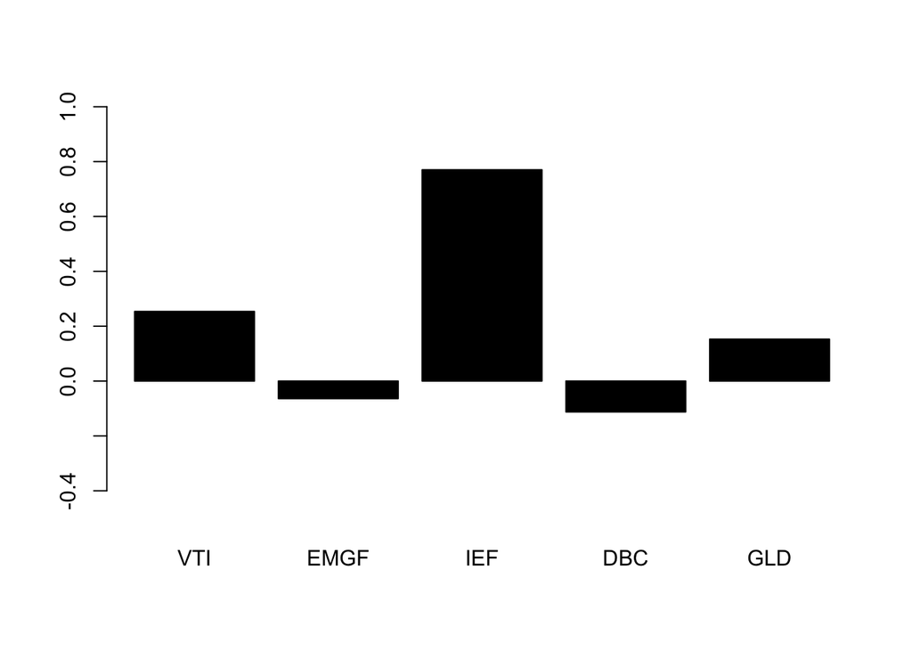

```r
# Plot of Tangency portfolio

barnames <- c("VTI", "EMGF", "IEF", "DBC", "GLD")
barplot(
  as.numeric(omega),
  col = 'Black',
  names.arg = barnames,
  ylim = c(-0.5, 1)
)
```

## 4.2 Implementing Black-Litterman approach

In order to construct our views matrix, we can base our assumptions on the economic outlooks provided from a group of asset managers to confront outlooks and assess their perspective on markets. We will delve deeper into the outlooks from BlackRock, Goldman Sachs Asset Management (GSAM), and J.P. Morgan Asset Management (JPMAM) on gold, international equities, commodities, short-term US Treasuries, and emerging markets:

**International equity markets**

International equity markets have underperformed US equity markets since 2019. However, they have started to outperform in 2023, as valuations have become more attractive and corporate earnings growth has picked up.

- **BlackRock:** BlackRock is neutral on international equities. The firm believes that international equities are undervalued, but it is cautious due to the risks associated with investing in international markets, such as currency fluctuations and political instability.
- **Goldman Sachs Asset Management (GSAM):** GSAM is neutral on international equities. The firm believes that international equities are undervalued, but it is cautious due to the risks associated with investing in international markets, such as currency fluctuations and political instability.
- **J.P. Morgan Asset Management (JPMAM):** JPMAM is overweight international equities. The firm believes that international equities are undervalued and that corporate earnings growth will pick up in the coming months.

**Emerging market equity**

Emerging market equity has underperformed US equity since 2019. However, it has started to outperform in 2023, as valuations have become more attractive and corporate earnings growth has picked up.

- **BlackRock:** BlackRock is neutral on emerging market equities. The firm believes that emerging market equities are undervalued, but it is cautious due to the risks associated with investing in emerging markets, such as currency fluctuations and political instability.
- **GSAM:** GSAM is underweight emerging market equities. The firm believes that emerging markets are more risky than developed markets due to their higher exposure to China and other emerging economies.
- **JPMAM:** JPMAM is underweight emerging market equities. The firm believes that emerging markets are more risky than developed markets due to their higher exposure to China and other emerging economies.

**US short-term treasuries**

US short-term treasuries have underperformed most other asset classes since 2019. This is due to the fact that interest rates have been rising during this period.

- **BlackRock:** BlackRock is overweight short-term US Treasuries. The firm believes that the outlook for short-term US Treasuries is positive, as the Federal Reserve is expected to continue raising interest rates to combat inflation.
- **GSAM:** GSAM is overweight short-term US Treasuries. The firm believes that the outlook for short-term US Treasuries is positive, as the Federal Reserve is expected to continue raising interest rates to combat inflation.
- **JPMAM:** JPMAM is neutral on short-term US Treasuries. The firm believes that the outlook for short-term US Treasuries is neutral, as the Federal Reserve is expected to continue raising interest rates, but yields are already relatively high.

**Commodities**

Commodities have outperformed most other asset classes since 2019. This is due to a number of factors, including strong demand from China and the ongoing war in Ukraine.

- **BlackRock:** BlackRock is overweight commodities. The firm believes that commodity prices will remain supported by strong demand from China and the ongoing war in Ukraine.
- **GSAM:** GSAM is overweight commodities. The firm believes that commodity prices will remain supported by strong demand from China and the ongoing war in Ukraine.
- **JPMAM:** JPMAM is overweight commodities. The firm believes that commodity prices will remain supported by strong demand from China and the ongoing war in Ukraine.

**Gold**

Gold has outperformed most other asset classes since 2019. This is due to a number of factors, including concerns about global economic growth, geopolitical tensions, and inflation.

- **BlackRock:** BlackRock is overweight gold in its portfolios. The firm believes that gold is a good hedge against inflation and geopolitical risk.
- **GSAM:** GSAM is overweight gold in its portfolios. The firm believes that gold is a good hedge against inflation and geopolitical risk.
- **JPMAM:** JPMAM is overweight gold in its portfolios. The firm believes that gold is a good hedge against inflation and geopolitical risk.

Table 1. Data from BlackRock, Goldman Sachs Asset Management (GSAM), and J.P. Morgan Asset Management (JPMAM), 2023.

| **Asset class** | **BlackRock** | **GSAM** | **JPMAM** |
| --- | --- | --- | --- |
| Gold | Overweight | Overweight | Overweight |
| International equities | Neutral | Neutral | Overweight |
| Commodities | Overweight | Overweight | Overweight |
| Short-term US Treasuries | Overweight | Overweight | Neutral |
| Emerging markets | Neutral | Underweight | Underweight |

In summary, our combined views suggest the following outlook scenario for each asset class:

```r
Q <- numeric(5)
Q[1] <- 0.05 # Strongly overweight for International equities (TICKER: VTI)
Q[2] <- -0.02 # Relatively underweight for Emerging Markets (TICKER: EMGF)
Q[3] <- 0.05 # Strongly overweight for US short term maturity bond (TICKER: IEF)
Q[4] <- -0.01 # Relatively underweight for Commodities (TICKER: DBC)
Q[5] <- 0.03 # Relatively overweight for Gold (TICKER: GLD)
tau <- 0.95
```

The Black-Litterman optimization approach is a widely-used method for improving the estimation of expected returns and making asset allocation decisions. It addresses the limitations of traditional mean-variance optimization by incorporating investor views and market equilibrium considerations. The following key steps are performed:

Mixed estimation of returns: The code starts by computing expected returns using mixed estimation. This means combining the market equilibrium-based returns (mu) with the views-based returns (Q) using a blending process. The parameter tau adjusts the strength of the blending. This approach allows investors to incorporate their subjective views on assets into the asset allocation process while considering the overall market dynamics.

Tactical allocation with views directly: This part of the code calculates the tactical asset allocation weights based on views directly. It uses a matrix A_Q and the matrix of uncertainty in views (omega_Q) to determine the optimal portfolio weights. These weights reflect the investor’s views on specific assets and are adjusted according to their confidence in those views.

Tactical allocation with mixed estimation: Similarly, this part calculates tactical asset allocation weights, but this time, it uses the mixed estimation approach. It calculates A_mixed and omega_mixed based on the mixed estimation of expected returns. This allows investors to take a balanced approach, combining both market equilibrium considerations and their own views in the asset allocation process.

Black-Litterman offers a flexible framework for investors to incorporate their insights and views while maintaining a connection to market equilibrium. It’s a valuable tool for optimizing portfolio allocation decisions, especially when investors have specific expectations or insights about the market.

Source [1] Black, F., & Litterman, R. B. (1992). Global portfolio optimization. Financial Analysts Journal, 48(5), 28-43.

```r
#Mixed estimation of returns

Omega <- diag(diag(Sigma), n, n)
mu_mixed <-
  solve(solve(tau * Sigma) + solve(Omega)) %*% (solve(tau * Sigma) %*% mu +
                                                  solve(Omega) %*% Q)

#Tactical allocation with views directly

A_Q <- t(e) %*% solve(Sigma) %*% Q
omega_Q <- 1 / as.numeric(A_Q) * solve(Sigma) %*% Q
#barplot(as.numeric(omega_Q), col = 'black', names.arg = barnames, ylim = c(-0.5,1.5))
```

We can add the following comments on the new portfolio allocation under Black-Litterman approach, including asset views.

**Comments on Portfolio Allocation**:

Overall, the portfolio allocation under the Black-Litterman approach takes into account a broader spectrum of views from different asset managers and integrates them into a more specific allocation that reflects varying degrees of optimism and caution across different asset classes. Incorporating views into the portfolio has resulted in diverse adjustments across asset classes, reflecting the investor’s evolving outlook on each. These changes are indicative of a dynamic strategy that aims to capitalize on various market scenarios. It’s crucial to consider these allocations within the context of the investor’s overall investment objectives and risk tolerance, as they play a pivotal role in shaping the portfolio’s risk-return profile.

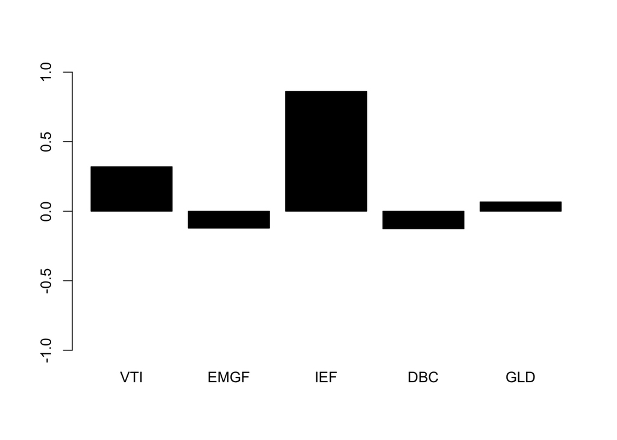

```r
#Tactical allocation with mixed estimation
A_mixed <- t(e) %*% solve(Sigma) %*% mu_mixed
omega_mixed <- 1 / as.numeric(A_mixed) * solve(Sigma) %*% mu_mixed
barplot(as.numeric(omega_mixed), col = 'black', names.arg = barnames, ylim = c(-1,1))
```